# Matplotlib

# 3- Types de figures

## Le nuage de points: scatter

Pour dessiner un nuage de points, il suffit de fournir les coordonnées x et y des points.

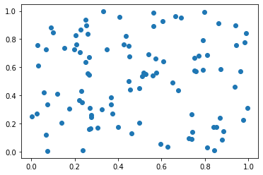

```python
x,y = np.random.rand(2,100)
plt.scatter(x,y)

plt.show()
```

Vous pouvez également indiquer l'échelle de chaque point.

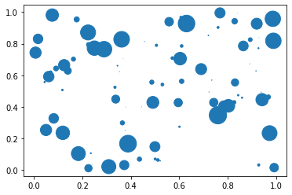

```python
x,y,scale = np.random.rand(3,100)
scale = 500*scale**5
plt.scatter(x,y,s=scale)
plt.show()
```

Et comme d'habitude, vous pouvez définir un certain nombre d'autres attributs, tels que les couleurs de remplissage et de bordure et le niveau alpha.

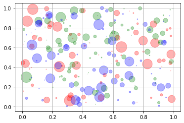

```python
for color in ['red','green','blue']:
    n = 100
    x,y = np.random.rand(2,n)
    scale=500*np.random.rand(n)**5
    plt.scatter(x,y,s =scale,c=color, alpha=0.3)

plt.grid()
plt.show()
```

Un dernier exemple avec la fleur d'iris

```
X contient 150 exemples et 4  variables
Il ya 3 classes
```

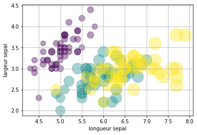

```python
from sklearn.datasets import load_iris


iris = load_iris()
X = iris.data
y = iris.target

## on affiche les informations de ces variables


names = list(iris.target_names)
print(f"X contient {X.shape[0]} exemples et {X.shape[1]}  variables")
print(f"Il ya {np.unique(y).size} classes")


plt.scatter(X[:,0],X[:,1], c=y, alpha=0.4, s=X[:,2]*100)

plt.xlabel("longueur sepal")
plt.ylabel("largeur sepal")

plt.grid()
plt.show()
```

## Histogramme

Ils sont tres importants lorsqu'on manipule les données. Ils nous permmetent de voir la distribution de nos donnees . Si la distribution est normale ou non, symétrique ou asymétrique ou bien encore de visualiser la moyennne. On peut voir comment les fleurs sont distribuées

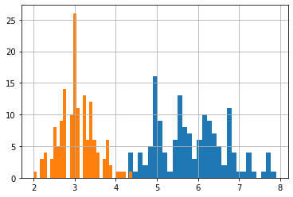

```python
# un exemple avec la fleur d'iris avec modification du nombre de bins

plt.hist(X[:,0], bins=30)
plt.hist(X[:,1], bins=30)
plt.grid()
plt.show()
```

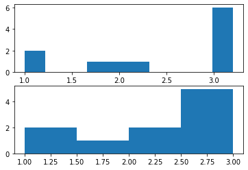

```python
#un autre exemple
data = [1, 1.1, 1.8,2,2.1,3.2,3,3,3,3,3]

plt.subplot(211)
plt.hist(data, bins = 10)

plt.subplot(212)
plt.hist(data, bins = [1, 1.5,2, 2.5,3])

plt.show()
```

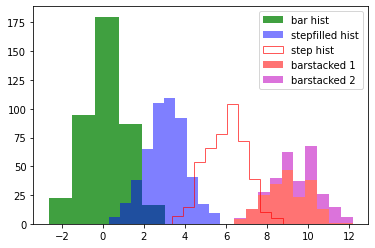

```python
data1 = np.random.randn(400)
data2 = np.random.randn(500) + 3
data3 = np.random.randn(450) + 6
data4 = np.random.randn(200) + 9
data5 = np.random.randn(100) + 10


plt.hist(data1, bins=5, color='g', alpha=0.75, label='bar hist') # par defaut
plt.hist(data2, color='b', alpha=0.5, histtype= 'stepfilled',label='stepfilled hist')
plt.hist(data3, color='r', alpha=0.65, histtype= 'step',label='step hist')
plt.hist((data4, data5), color=('r','m'), alpha=0.55, histtype= 'barstacked',
         label=('barstacked 1', 'barstacked 2'))



plt.legend()
plt.show()
```

Il y a aussi différents types d'histogrammmes et un certains nombres de paramètres qu'on peut modifier

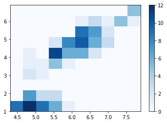

```python
plt.hist2d(X[:,0],X[:,2], cmap= 'Blues')
plt.colorbar()
plt.show()
```

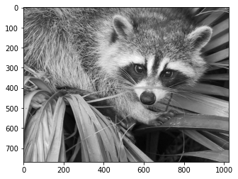

```python
from scipy import misc

face = misc.face(gray=True)
plt.imshow(face, cmap= 'gray')
plt.show()
```

On utilise les histogramme pour faire de l'analyse d'images :

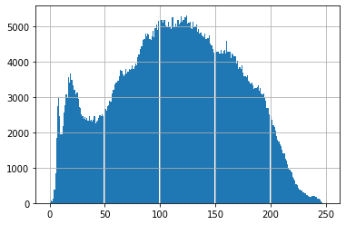

```python
plt.hist(face.ravel(), bins=255)
plt.grid()
plt.show()
```

# Images

Lire, générer et tracer des images dans matplotlib est assez simple.

Pour lire une image, il suffit d'importer le $\textbf{module matplotlib.image}$, et d'appeler sa fonction $\textbf{imread}$, en lui passant le nom du fichier (ou l'objet fichier). Cela renvoie les données de l'image, sous la forme d'un tableau NumPy. Essayons ceci avec l'image $\textbf{ma_figure.png}$ que nous avons sauvegardée plus tôt.

```
(288, 432, 4)
float32
```

[figure not shown]

```python
import matplotlib.image as mpimg
img = mpimg.imread('ma_figure.png')

print(img.shape)
print(img.dtype)



plt.imshow(img)
# plt.imshow('off')
plt.show()
```

# la fonction imshow() permet d'afficher une matrice de correlation

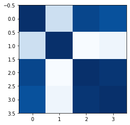

```python
plt.imshow(np.corrcoef(X.T), cmap="Blues")
plt.show()
```

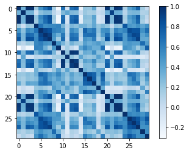

```python
from sklearn.datasets import load_breast_cancer
cancer = load_breast_cancer()

X = cancer.data

plt.imshow(np.corrcoef(X.T), cmap="Blues")
plt.colorbar()
plt.show()
```

On peut créer notre propre image

```
[[   0    1    2 ...   97   98   99]
 [ 100  101  102 ...  197  198  199]
 [ 200  201  202 ...  297  298  299]
 ...
 [9700 9701 9702 ... 9797 9798 9799]
 [9800 9801 9802 ... 9897 9898 9899]
 [9900 9901 9902 ... 9997 9998 9999]]
```

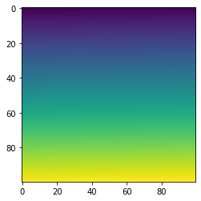

```python
img = np.arange(100*100).reshape(100,100)
print(img)
plt.imshow(img)
plt.show()
```

[figure not shown]

```python
img = np.empty((20,30,3))
img[:,:10] = [0,0,0.6]
img[:,10:20] = [1,1,1]
img[:,20:] = [0.6,0,0]

plt.imshow(img)
plt.show()
```

Vous pouvez souhaiter masquer les axes lorsque vous affichez une image :

[figure not shown]

```python
plt.imshow(img)
plt.axis('off')
plt.show()
```

On peut generer notre propre image

[figure not shown]

```python
img = np.empty((20,30,3))
img[:,:10] = [0,0,0.6]
img[:,10:20] = [1,1,1]
img[:,20:] = [0.6,0,0]

plt.imshow(img, interpolation="nearest")
plt.axis('off')
plt.show()
```

## Figure en 3D

Pour tracer des graphiques en 3D vous devez importer Axes3D, qui enregistre la projection "3d". Ensuite, créez un sous-plot en fixant la projection à "3d". Cela renvoie un objet Axes3DSubplot, que vous pouvez utiliser pour appeler plot_surface, en donnant des coordonnées x, y et z, ainsi que des attributs optionnels.

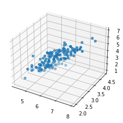

```python
# exemple avec la fleur d'iris

from mpl_toolkits.mplot3d import Axes3D
from sklearn.datasets import load_iris


iris = load_iris()
X = iris.data
y = iris.target


ax = plt.axes(projection = '3d')
ax.scatter(X[:,0],X[:,1],X[:,2])
plt.show()
```

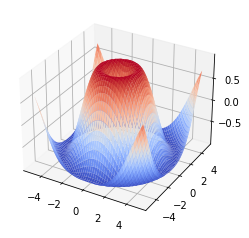

```python
# un autre exemple
x = np.linspace(-5,5,50)
y = np.linspace(-5,5,50)
X,Y= np.meshgrid(x,y)


R = np.sqrt(X**2 +Y**2)
Z = np.sin(R)


figure = plt.figure(1, figsize = (12,4))
subplot3d = plt.subplot(111, projection='3d')
surface = subplot3d.plot_surface(X,Y,Z, cmap= plt.cm.coolwarm)
plt.show()
```

Une autre façon d'afficher ces mêmes données est d'utiliser un tracé de contour.

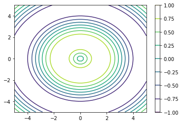

```python
# un autre exemple pour finir :  une surface
plt.contour(X,Y,Z)
plt.colorbar()
plt.show()
```

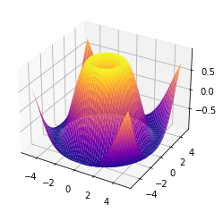

```python
ax = plt.axes(projection = '3d')
ax.plot_surface(X,Y,Z, cmap="plasma")
```

Vue de dessus d'un 3D : contour plot

```python
f = lambda x, y : np.sin(x) + np.cos(x+y)*np.cos(x)


X = np.linspace(0,5,200)
Y = np.linspace(0,5,200)


XX,YY = np.meshgrid(X,Y)


Z = f(XX,YY)
```

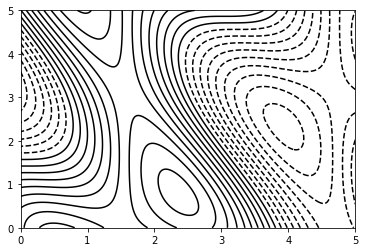

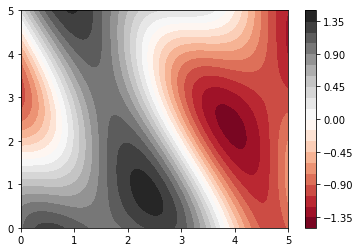

```python
plt.contour(XX,YY,Z,20,colors='black')

plt.show()


plt.contourf(XX,YY,Z,20,cmap='RdGy')
plt.colorbar()

plt.show()
```

Mais lorsque vous écrivez un programme, l'explicite est préférable à l'implicite. Le code explicite est généralement plus facile à déboguer et à maintenir, et si vous ne me croyez pas, lisez la deuxième règle du Zen of Python :

```python
import this
```

```
The Zen of Python, by Tim Peters

Beautiful is better than ugly.
Explicit is better than implicit.
Simple is better than complex.
Complex is better than complicated.
Flat is better than nested.
Sparse is better than dense.
Readability counts.
Special cases aren't special enough to break the rules.
Although practicality beats purity.
Errors should never pass silently.
Unless explicitly silenced.
In the face of ambiguity, refuse the temptation to guess.
There should be one-- and preferably only one --obvious way to do it.
Although that way may not be obvious at first unless you're Dutch.
Now is better than never.
Although never is often better than *right* now.
If the implementation is hard to explain, it's a bad idea.
If the implementation is easy to explain, it may be a good idea.
Namespaces are one honking great idea -- let's do more of those!
```

## on peut aller plus loin en faisant des animations : voir la doc de matplotlib